# Facets

# 1 Learning Objectives

- Know what facets are and when to use them.
- Be able to create ggplot2 plots with facets.

**Duration - 1 hour**

# 2 Facetting

Faceting is converting one plot into multiple related plots. This helps ease clarity of data, and provides a convienent and quick way to group data into related categories. *If you ask R programmers why they like `ggplot2`, they tend to mention ease of facetting.*

You do this with the function `facet_wrap()`. The basic `facet_wrap` function still has structured syntax:

```
facet_wrap(
   facets,        #   specify the variables to facet with respect to
   nrow = NULL,   #   number of rows in facet grid
   ncol = NULL,   #   number of columns in facet grid
   ...
)
```

This is easiest to explain how to use it is with an example.

## 2.1 Using `facet_wrap()`

Let’s look at the weights of chickens given different foods.

The basic line plot we made is a bit hard to follow, because there are too many lines

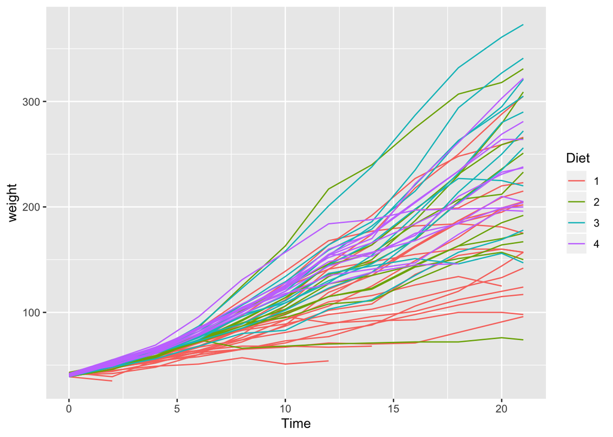

```r
library(ggplot2)

ggplot(ChickWeight) +
  aes(x = Time, y = weight, group = Chick, colour = Diet) +
  geom_line()
```

Rather than just relying on colours, let’s break it down into multiple graphs using facets.

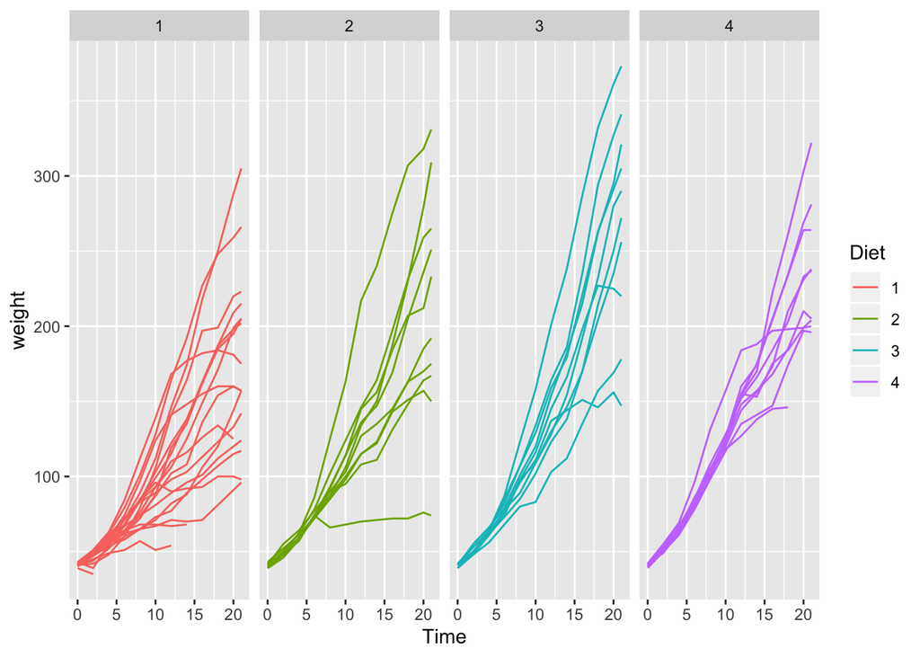

```r
ggplot(ChickWeight) +
  aes(x = Time, y = weight, group = Chick, colour = Diet) +
  geom_line() +
  facet_wrap(~ Diet, ncol = 4)
```

In the example above we tell `ggplot2` to facet by `Diet`. It determines the number of levels of `Diet` (which in this case is = 4) and produces this many subplots. Each subplot is assigned a level, and only observations with that level of `Diet` are included in that subplot.

Note that the common scale makes comparison between the graphs easier. We don’t even need the colours any more, although they make the plots look better so let’s keep them.

> **Task - 5 mins**

> Open up the `benefits` data from the `CodeClanData` package.

> ```r
> library(CodeClanData)
> benefits <- Benefits
> ```

> Use `geom_histogram` to create a histogram showing the number of unemployed by age. Then facet the graph based on biological `sex`. *Hint: `geom_histogram` is almost the same as `geom_bar`, but is better suited to plotting continous data.*

> **Answer**

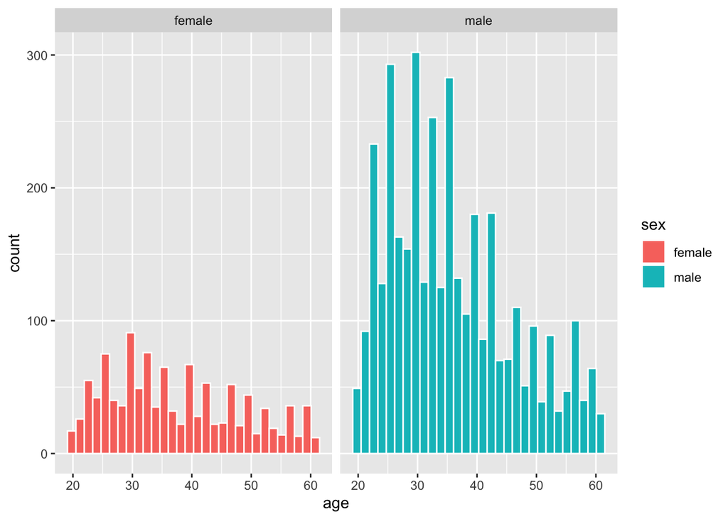

> ```r
> ggplot(benefits) +
> geom_histogram(aes(x = age, fill = sex), col = "white") +
> facet_wrap(~ sex, ncol = 2)
> ```

So we can condition on a single variable easily using `facet_wrap()`. But we can also condition on two variables. For this, we use `facet_grid()`.

## 2.2 `facet_grid()`

Let’s plot our data splitting it out by biological `sex` **and** marital status (`married`).

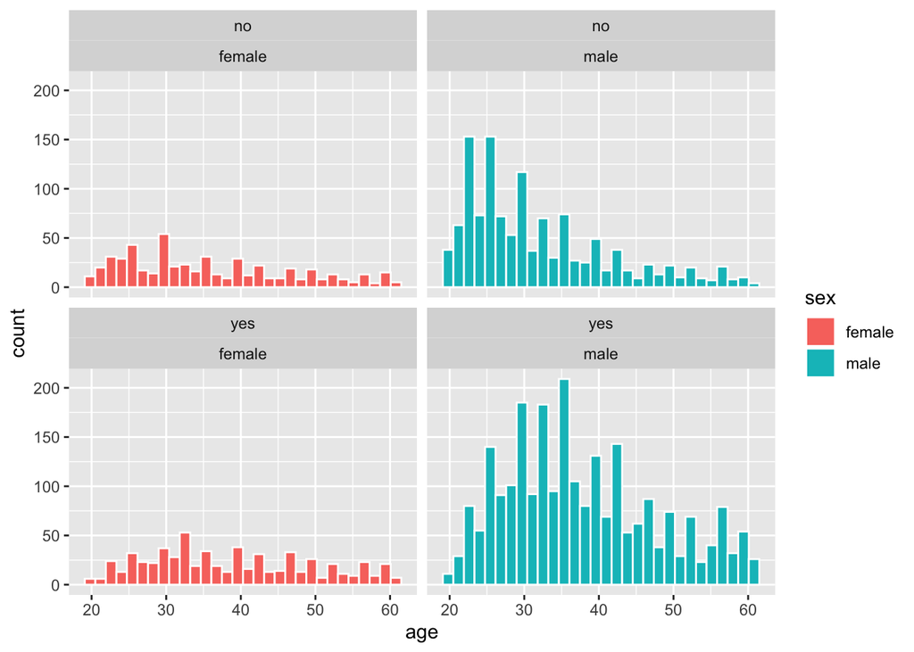

```r
ggplot(benefits) +
  geom_histogram(aes(x = age, fill = sex), col = "white") +
  facet_wrap(married ~ sex)
```

Note the layout means we can compare y-values more easily between columns, and x-values more easily between rows. Whether than’s an advantage will obviously depend on the problem. Bear it in mind though.

> **Task - 5 mins**
> 1. Use the same dataset, but base the `facet_grid()` on marital status (married) and if the individual has children (`dkids`).
> 2. Extension: can you improve the way that the facets are labled.

> **Hint**

> ?labeller

> **Answer**

> 1.

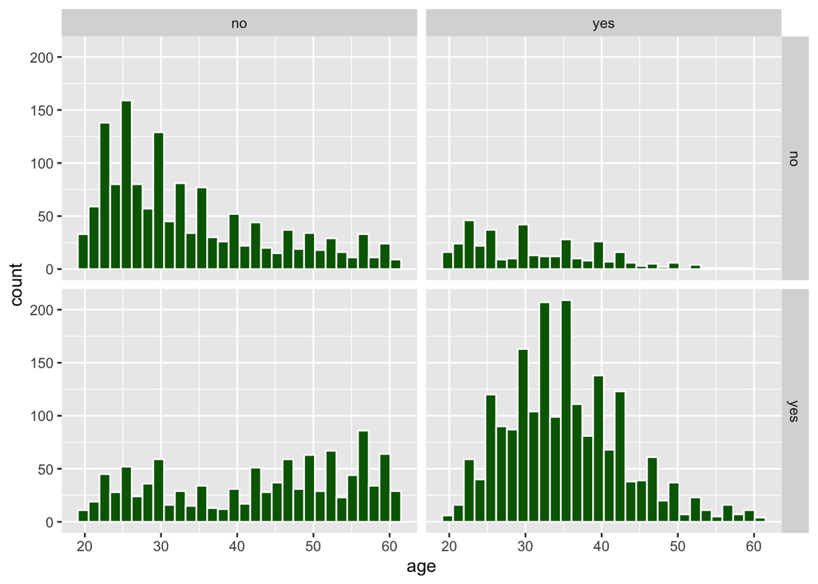

> ```r
> ggplot(benefits) +
> geom_histogram(aes(x = age), col = "white", fill = "dark green")  +
> facet_grid(married ~ dkids)
> ```

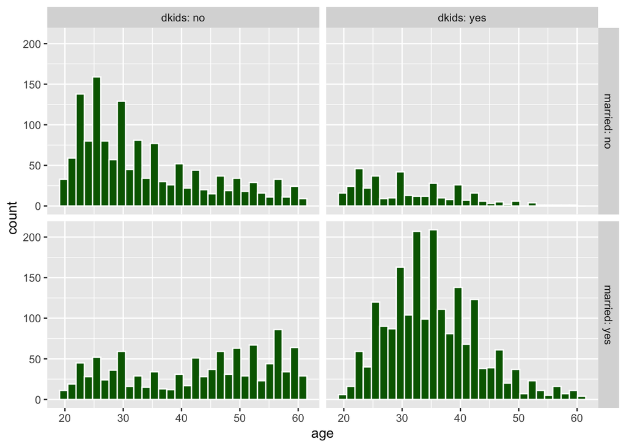

> ```r
> ggplot(benefits) +
> geom_histogram(aes(x = age), col = "white", fill = "dark green")  +
> facet_grid(married ~ dkids, labeller = "label_both")
> ```

## 2.3 Additional facetting options - scales and space

By default facets are plotted on the same scale and are allocated the same area. This isn’t always the desired outcome.

(This argument is set to `"fixed"` by default.)

Let’s look at an example:

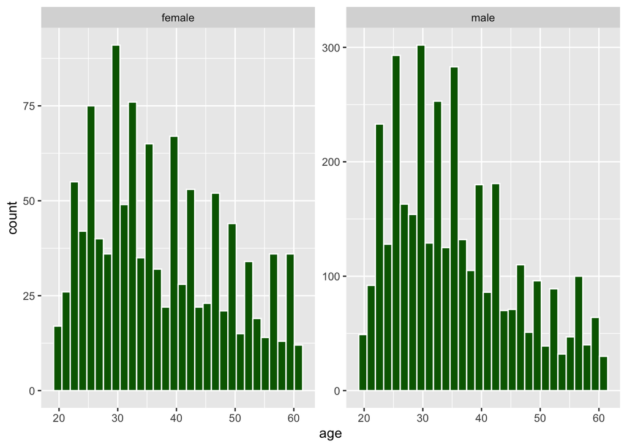

```r
ggplot(benefits) +
  geom_histogram(aes(x = age), col = "white", fill = "dark green") +
  facet_wrap(~ sex, ncol = 2, scales = "free_y")
```

> **Task - 2 mins**

> Why might this not be ideal?

> **Answers**

> It’s more difficult to compare facets now! You need to be VERY careful with this technique.

## 2.4 Continuous Variables

Up until now, we’ve used the facet functions to split the plots out by discrete variables: that is, variables that take on discrete values, or that are categories. But suppose we want to facet with respect to a continuous variable (one that can take on any value). Basically, you can’t as you’d end up with too many plots with (probably) only a single point on them. But you can discretise the variable. `ggplot2` includes 3 helper functions for doing this:

`cut_interval(x,n)` : divides the data into `n` bins, each of the same width  
`cut_width(x,width)` : divides the data into bins of width `width`  
`cut_number(x,n=10)` : divides the data into `n` bins each containing roughly the same number of points

**Example:** Let’s go back to the unemployed Americans and breakdown the age distribution by years of tenure in job lost.

```r
library(dplyr)

benefits <-
benefits %>%
  mutate(
    tenure_interval = cut_interval(tenure, 4),
    tenure_width = cut_width(tenure, 15),
    tenure_number = cut_number(tenure, 4)
  )
benefits %>%
  select(age, tenure, tenure_interval, tenure_width, tenure_number)
```

| age | tenure | tenure_interval | tenure_width | tenure_number |
| --- | --- | --- | --- | --- |
| 49 | 21 | (11,21] | (7.5,22.5] | (7,41] |
| 26 | 2 | [1,11] | [-7.5,7.5] | [1,2] |
| 40 | 19 | (11,21] | (7.5,22.5] | (7,41] |
| 51 | 17 | (11,21] | (7.5,22.5] | (7,41] |
| 33 | 1 | [1,11] | [-7.5,7.5] | [1,2] |
| 51 | 3 | [1,11] | [-7.5,7.5] | (2,3] |
| 30 | 5 | [1,11] | [-7.5,7.5] | (3,7] |
| 26 | 3 | [1,11] | [-7.5,7.5] | (2,3] |
| 54 | 20 | (11,21] | (7.5,22.5] | (7,41] |
| 31 | 1 | [1,11] | [-7.5,7.5] | [1,2] |

[output cut: 4867 more lines]

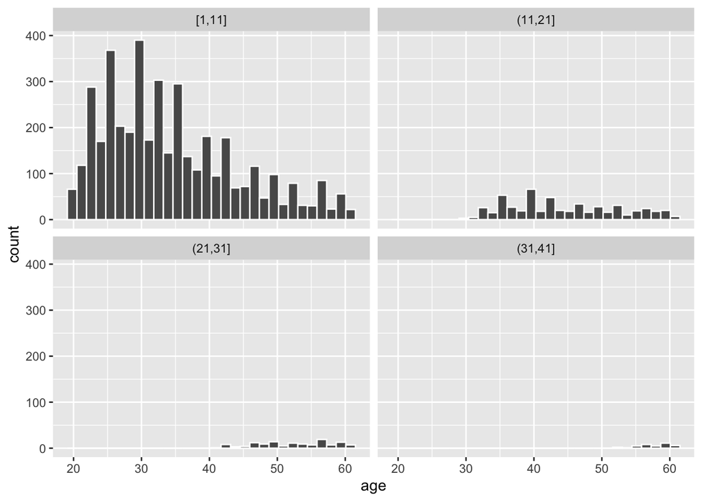

```r
ggplot(benefits) +
  geom_histogram(aes(x = age), col = "white") +
  facet_wrap(~ tenure_interval)
```

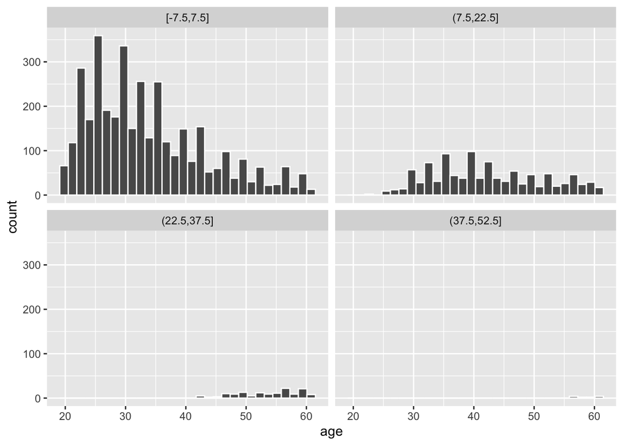

```r
ggplot(benefits) +
  geom_histogram(aes(x = age), col = "white") +
  facet_wrap(~ tenure_width)
```

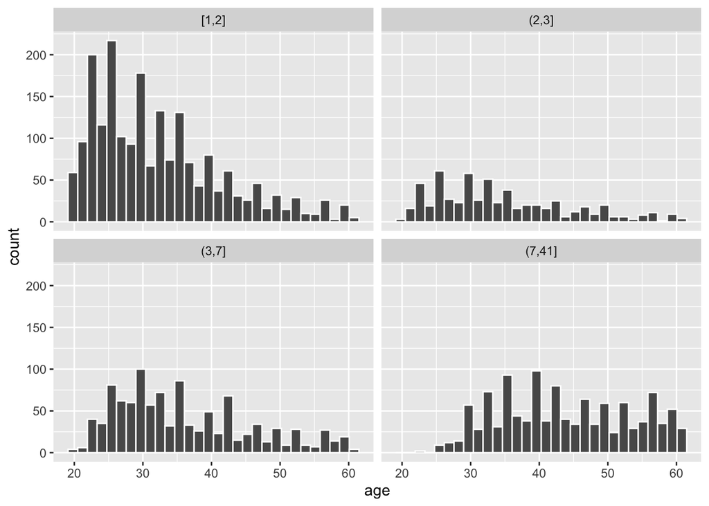

```r
ggplot(benefits) +
  geom_histogram(aes(x = age), col = "white") +
  facet_wrap(~ tenure_number)
```

# 3 Recap

- What’s the point of facets?

**Answer**

- Facets split up a plot into smaller subplots in a format that eases comparison between subplots, by conditioning on some variable(s) in the dataset.
- How do we introduce facets to a `ggplot` call?

**Answer**

We can use `facet_wrap()` or `facet_grid()` at the end of the call.

# 4 Additional Resources

Links of where else to look

- [ggplot2 home page](https://ggplot2.tidyverse.org)